# Auswertung

27 September 2015

# 1 Datensätze: gesamt, init und monitoring

```r
# Zuerst müssen wir die Gesamttabelle einlesen und die Datentypen gemäß werte.csv korrigieren.
gesamt <- read.csv("gesamttabelle.csv", header=T)

# korrigiere Datentypen
gesamt$gpsr  <- as.double(gesamt$gpsr)
gesamt$gpsh  <- as.double(gesamt$koa)
gesamt$koa  <- as.factor(gesamt$koa)
gesamt$kod  <- as.factor(gesamt$kod)
gesamt$wt  <- as.numeric(gesamt$wt)
gesamt$vn  <- as.factor(gesamt$vn)
gesamt$aves  <- as.factor(gesamt$aves)
gesamt$mamm  <- as.factor(gesamt$mamm)
gesamt$invert  <- as.factor(gesamt$invert)
gesamt$flkot  <- as.factor(gesamt$flkot)
gesamt$qtyp  <- as.factor(gesamt$qtyp)

# Subsets für 2010 und 2011 bis 2015
init  <- subset(gesamt, koa == 10)
monitoring  <- subset(gesamt, koa != 10)
```

Es liegen drei Datensätze vor:

- **gesamt** umfasst alle Kontrolldaten von 2010 bis 2015
- **init** umfasst die Daten von der initialen Untersuchung 2010 (gesamtes Untersuchungsgebiet)
- **monitoring** umfasst die Daten aus dem Monitoring (2011 bis 2015), in welchem einige Gebiete zweimal einige nur einmal untersucht, wenige nicht vollständig wurden.

Um die Bestandsentwicklung beurteilen zu können, wird ein Korrekturfaktor `corr <- length(init$kid) / length(monitoring$kid)` für die Differenz-Daten, die nach der Formel **diff = corr * (monitoring - init)** aus den Auswertungsdaten gebildet werden, so realistisch wie möglich darzustellen.

```r
corr <- length(init$kid) / length(monitoring$kid)
```

# 2 Welche Arten haben ihre Sommerquartiere im Untersuchungsgebiet?

```r
# Hierfür brauchen wir Datensätze, die nur die Zeilen enthalten, in denen eine Art bestimmt wurde.
gesamt.flart <- subset(gesamt, flart != 0)
init.flart <- subset(init, flart != 0)
monitoring.flart <- subset(monitoring, flart != 0)
```

```r
levels(gesamt.flart$flart)
```

```
##  [1] "0"                     "M.daubentonii"
##  [3] "M.myotis"              "M.mystacinus/brandtii"
##  [5] "M.nattereri"           "Nyc.noctula"
##  [7] "Pip"                   "Pip.nathusii"
##  [9] "Pip.pygmaeus"          "Plec.auritus"
```

Von 2010 bis 2015 wurden acht Arten sowie nicht weiter bestimmte *Pipistrellus*-Arten gefunden:

- Wasserfledermaus (*Myotis daubentonii*)
- Großes Mausohr (*Myotis myotis*)
- Bartfledermäuse (*Myotis mystacinus* oder *Myotis brandtii*)
- Fransenfledermaus (*Myotis nattereri*)
- Großer Abernsegler (*Nyctalus noctula*)
- Rauhautfledermaus (*Pipistrellus nathusii*)
- Mückenfledermaus (*Pipistrellus pygmaeus*)
- Braunes Langohr (*Plecotus auritus*)

## 2.1 Quartiere pro Art

```r
gesamt.quartiere <- summary(gesamt.flart$flart)[-1]
init.quartiere <- summary(init.flart$flart)[-1]
monitoring.quartiere <- summary(monitoring.flart$flart)[-1]
diff.quartiere <- corr * (monitoring.quartiere - init.quartiere)
Quartiere <- data.frame(
            gesamt.quartiere,
            init.quartiere,
            monitoring.quartiere,
            diff.quartiere
            )
names(Quartiere) <- c("gesamt", "init", "monitoring", "diff")
library(xtable)
Table1 <- xtable(
         Quartiere,
         caption="Tabelle 1: Quartiere pro Art",
         digits=0
         )
print(Table1, type="html")
```

Tabelle 1: Quartiere pro Art

|  | gesamt | init | monitoring | diff |
| --- | --- | --- | --- | --- |
| M.daubentonii | 16 | 1 | 15 | 7 |
| M.myotis | 5 | 2 | 3 | 0 |
| M.mystacinus/brandtii | 1 | 1 | 0 | -0 |
| M.nattereri | 74 | 15 | 59 | 21 |
| Nyc.noctula | 1 | 1 | 0 | -0 |
| Pip | 1 | 0 | 1 | 0 |
| Pip.nathusii | 2 | 2 | 0 | -1 |
| Pip.pygmaeus | 2 | 0 | 2 | 1 |
| Plec.auritus | 13 | 8 | 5 | -1 |

Die Quartierverteilung weist auf eine Bestandszunahme bei Wasser- und Fransenfledermaus hin, wobei bei letzerer Doppelzählungen als Zeitreiheneffekte ausschlaggebend sein können.

## 2.2 Individuen pro Art

```r
# jeweils flart und flges in einem data.frame
g <- aggregate(gesamt.flart$flges, by=list(flart=gesamt.flart$flart), FUN=sum)
i <- aggregate(init.flart$flges, by=list(flart=init.flart$flart), FUN=sum)
m <- aggregate(monitoring.flart$flges, by=list(flart=monitoring.flart$flart), FUN=sum)

# alle beobachteten Arten
Art <- g$flart

# Die Counts für den Gesamtzeitraum
count.gesamt <- g$x

# für 2010
i.1 <- subset(i, flart=="M.daubentonii", select=x)$x
i.2 <- subset(i, flart=="M.myotis")$x
i.3 <- subset(i, flart=="M.mystacinus/brandtii")$x
i.4 <- subset(i, flart=="M.nattereri")$x
i.5 <- subset(i, flart=="Nyc.noctula")$x
i.6 <- 0
i.7 <- subset(i, flart=="Pip.nathusii")$x
i.8 <- 0
i.9 <- subset(i, flart=="Plec.auritus")$x
count.init <- c(i.1,i.2,i.3,i.4,i.5,i.6,i.7,i.8,i.9)

# für 2011 bis 2015
m.1 <- subset(m, flart=="M.daubentonii")$x
m.2 <- subset(m, flart=="M.myotis")$x
m.3 <- 0
m.4 <- subset(m, flart=="M.nattereri")$x
m.5 <- 0
m.6 <- subset(m, flart=="Pip")$x
m.7 <- 0
m.8 <- subset(m, flart=="Pip.pygmaeus")$x
m.9 <- subset(m, flart=="Plec.auritus")$x
count.monitoring <- c(m.1,m.2,m.3,m.4,m.5,m.6,m.7,m.8,m.9)

# Bestandsentwicklung
count.diff <- corr * (count.monitoring - count.init)

# alles in einem data.frame
Art.count <- data.frame(Art, count.gesamt, count.init, count.monitoring, count.diff)
names(Art.count) <- c("Art","gesamt", "init", "monitoring", "diff")
Table2 <- xtable(
         Art.count,
         caption="Tabelle 2: gezählte Individuen pro Art",
         digits=0
         )
print(Table2, type="html")
```

Tabelle 2: gezählte Individuen pro Art

|  | Art | gesamt | init | monitoring | diff |
| --- | --- | --- | --- | --- | --- |
| 1 | M.daubentonii | 107 | 1 | 106 | 50 |
| 2 | M.myotis | 6 | 2 | 4 | 1 |
| 3 | M.mystacinus/brandtii | 4 | 4 | 0 | -2 |
| 4 | M.nattereri | 470 | 118 | 352 | 111 |
| 5 | Nyc.noctula | 3 | 3 | 0 | -1 |
| 6 | Pip | 1 | 0 | 1 | 0 |
| 7 | Pip.nathusii | 2 | 2 | 0 | -1 |
| 8 | Pip.pygmaeus | 2 | 0 | 2 | 1 |
| 9 | Plec.auritus | 102 | 76 | 26 | -24 |

```r
# und die Prozente ...

# Die Prozente ermitteln sich durch den Vector dividiert durch einen Vector der selben Länge, der nur die Vectorsumme enthält.
percent.gesamt <- count.gesamt / rep(sum(count.gesamt), length(count.gesamt)) *100
percent.init <- count.init / rep(sum(count.init), length(count.init)) *100
percent.monitoring <- count.monitoring / rep(sum(count.monitoring), length(count.monitoring)) *100

# Bestandsentwicklung
percent.diff <- percent.monitoring - percent.init

# alles in einem data.frame
Art.percent <- data.frame(Art, percent.gesamt, percent.init, percent.monitoring, percent.diff)
names(Art.percent) <- c("Art","gesamt", "init", "monitoring", "diff")
Table3 <- xtable(
         Art.percent,
         caption="Tabelle 3: Prozente der Arten an den gesamt gezählten Individuen",
         digits=c(0, 0, rep(2, 4))
         )
print(Table3, type="html")
```

Tabelle 3: Prozente der Arten an den gesamt gezählten Individuen

|  | Art | gesamt | init | monitoring | diff |
| --- | --- | --- | --- | --- | --- |
| 1 | M.daubentonii | 15.35 | 0.49 | 21.59 | 21.10 |
| 2 | M.myotis | 0.86 | 0.97 | 0.81 | -0.16 |
| 3 | M.mystacinus/brandtii | 0.57 | 1.94 | 0.00 | -1.94 |
| 4 | M.nattereri | 67.43 | 57.28 | 71.69 | 14.41 |
| 5 | Nyc.noctula | 0.43 | 1.46 | 0.00 | -1.46 |
| 6 | Pip | 0.14 | 0.00 | 0.20 | 0.20 |
| 7 | Pip.nathusii | 0.29 | 0.97 | 0.00 | -0.97 |
| 8 | Pip.pygmaeus | 0.29 | 0.00 | 0.41 | 0.41 |
| 9 | Plec.auritus | 14.63 | 36.89 | 5.30 | -31.60 |

In Tabelle 2 und 3 bestätigt sich das Bild von Tabelle 1. Was jedoch auch deutlich wird ist ein Rückgang des Braunen Langohrs um über 30 Prozent. Das kann durchaus ein blöder Zufall sein, da hier nur 3 Quartiere nicht wieder gefunden wurden, aber über vier Jahre hinweg doch eher unwahrscheinlich, angesichts der Tatsache, dass die Wochenstuben sich auch in Teilkolonien aufsplitten.

## 2.3 Wochenstuben pro Art

Da unser Hauptaugenmerk auf den Wochenstuben liegt betrachten wir die Situation noch einmal separat für selbige.

```r
# nur Daten, die Wochenstuben beinhalten
gesamt.ws <- subset(gesamt.flart, qtyp == 5)
init.ws <- subset(init.flart, qtyp == 5)
monitoring.ws <- subset(monitoring.flart, qtyp == 5)
```

```r
gesamt.ws.quartiere <- summary(gesamt.ws$flart)[-1]
init.ws.quartiere <- summary(init.ws$flart)[-1]
monitoring.ws.quartiere <- summary(monitoring.ws$flart)[-1]
diff.ws.quartiere <- corr * (monitoring.ws.quartiere - init.ws.quartiere)

Wochenstuben<- data.frame(
            gesamt.ws.quartiere,
            init.ws.quartiere,
            monitoring.ws.quartiere,
            diff.ws.quartiere
            )
names(Wochenstuben) <-  c("gesamt", "init", "monitoring", "diff")
Table3 <- xtable(
         Wochenstuben,
         caption="Tabelle 3: Wochenstuben pro Art",
         digits=0
         )
print(Table3, type="html")
```

Tabelle 3: Wochenstuben pro Art

|  | gesamt | init | monitoring | diff |
| --- | --- | --- | --- | --- |
| M.daubentonii | 9 | 0 | 9 | 4 |
| M.myotis | 0 | 0 | 0 | 0 |
| M.mystacinus/brandtii | 1 | 1 | 0 | -0 |
| M.nattereri | 38 | 8 | 30 | 10 |
| Nyc.noctula | 1 | 1 | 0 | -0 |
| Pip | 0 | 0 | 0 | 0 |
| Pip.nathusii | 0 | 0 | 0 | 0 |
| Pip.pygmaeus | 0 | 0 | 0 | 0 |
| Plec.auritus | 11 | 6 | 5 | -0 |

Das Bild entspricht dem der Quartiere insgesamt.

## 2.4 Individuen pro Wochenstube

```r
# jeweils flart und flges in einem data.frame
g <- aggregate(gesamt.ws$flges, by=list(flart=gesamt.ws$flart), FUN=sum)
i <- aggregate(init.ws$flges, by=list(flart=init.ws$flart), FUN=sum)
m <- aggregate(monitoring.ws$flges, by=list(flart=monitoring.ws$flart), FUN=sum)

# alle beobachteten Arten
Art <- g$flart

# Die Counts für den Gesamtzeitraum
count.gesamt <- g$x

# für 2010
i.1 <- 0
i.2 <- subset(i, flart=="M.mystacinus/brandtii")$x
i.3 <- subset(i, flart=="M.nattereri")$x
i.4 <- subset(i, flart=="Nyc.noctula")$x
i.5 <- subset(i, flart=="Plec.auritus")$x
count.init <- c(i.1,i.2,i.3,i.4,i.5)

# für 2011 bis 2015
m.1 <- subset(m, flart=="M.daubentonii")$x
m.2 <- 0
m.3 <- subset(m, flart=="M.nattereri")$x
m.4 <- 0
m.5 <- subset(m, flart=="Plec.auritus")$x
count.monitoring <- c(m.1,m.2,m.3,m.4,m.5)

# Bestandsentwicklung
count.diff <- corr * (count.monitoring - count.init)

# alles in einem data.frame
Art.count <- data.frame(Art, count.gesamt, count.init, count.monitoring, count.diff)
names(Art.count) <- c("Art","gesamt", "init", "monitoring", "diff")
Table4 <- xtable(
         Art.count,
         caption="Tabelle 4: gezählte Individuen pro Art in den Wochenstuben",
         digits=0
         )
print(Table4, type="html")
```

Tabelle 4: gezählte Individuen pro Art in den Wochenstuben

|  | Art | gesamt | init | monitoring | diff |
| --- | --- | --- | --- | --- | --- |
| 1 | M.daubentonii | 94 | 0 | 94 | 45 |
| 2 | M.mystacinus/brandtii | 4 | 4 | 0 | -2 |
| 3 | M.nattereri | 405 | 108 | 297 | 90 |
| 4 | Nyc.noctula | 3 | 3 | 0 | -1 |
| 5 | Plec.auritus | 98 | 72 | 26 | -22 |

```r
# und die Prozente ...

# Die Prozente ermitteln sich durch den Vector dividiert durch einen Vector der selben Länge, der nur die Vectorsumme enthält.
percent.gesamt <- count.gesamt / rep(sum(count.gesamt), length(count.gesamt)) *100
percent.init <- count.init / rep(sum(count.init), length(count.init)) *100
percent.monitoring <- count.monitoring / rep(sum(count.monitoring), length(count.monitoring)) *100

# Bestandsentwicklung
percent.diff <- percent.monitoring - percent.init

# alles in einem data.frame
Art.percent <- data.frame(Art, percent.gesamt, percent.init, percent.monitoring, percent.diff)
names(Art.percent) <- c("Art","gesamt", "init", "monitoring", "diff")
Table5 <- xtable(
         Art.percent,
         caption="Tabelle 5: Prozente der Arten an den in den Wochenstuben gezählten Individuen",
         digits=c(0, 0, rep(2, 4))
         )
print(Table5, type="html")
```

Tabelle 5: Prozente der Arten an den in den Wochenstuben gezählten Individuen

|  | Art | gesamt | init | monitoring | diff |
| --- | --- | --- | --- | --- | --- |
| 1 | M.daubentonii | 15.56 | 0.00 | 22.54 | 22.54 |
| 2 | M.mystacinus/brandtii | 0.66 | 2.14 | 0.00 | -2.14 |
| 3 | M.nattereri | 67.05 | 57.75 | 71.22 | 13.47 |
| 4 | Nyc.noctula | 0.50 | 1.60 | 0.00 | -1.60 |
| 5 | Plec.auritus | 16.23 | 38.50 | 6.24 | -32.27 |

Auch hier exakt das gleiche Bild wie bei allen Quartiertypen.

# 3 Wo sind die Verbreitungsschwerpunkte?

```r
# Die Anzahl der Quartiere entspricht der Anzahl von Fledermausfunden, daher, können wir mit den Datensätzen arbeiten.
gesamt.schlag <- summary(gesamt.flart$schlag, na.rm=T)
init.schlag <- summary(init.flart$schlag, na.rm=T)
monitoring.schlag <- summary(monitoring.flart$schlag, na.rm=T)
diff.schlag <- corr * (monitoring.schlag - init.schlag)

kuerzel <- names(gesamt.schlag)
schlag <- c(
        "Buchbeg",
        "Blaues Kreuz",
        "Eberhard",
        "Großholz",
        "Höckenbach",
        "Hochgementel",
        "Herr König",
        "Höger Zaun",
        "Kirchenholz",
        "Klemmtaferl",
        "Klosterhau",
        "Mitterbachl",
        "Rotes Kreuz",
        "Schöngraben",
        "Sulzschlag"
        )
Schlag <- data.frame(
             kuerzel,
             schlag
             )
Table6 <- xtable(
         Schlag,
         caption="Tabelle 6: Abkürzungen für die Schläge",
         digits=0
         )
print(Table6, type="html")
```

Tabelle 6: Abkürzungen für die Schläge

|  | kuerzel | schlag |
| --- | --- | --- |
| 1 | bb | Buchbeg |
| 2 | bk | Blaues Kreuz |
| 3 | e | Eberhard |
| 4 | g | Großholz |
| 5 | hb | Höckenbach |
| 6 | hk | Hochgementel |
| 7 | ho | Herr König |
| 8 | hz | Höger Zaun |
| 9 | ki | Kirchenholz |
| 10 | kle | Klemmtaferl |
| 11 | klo | Klosterhau |
| 12 | m | Mitterbachl |
| 13 | rk | Rotes Kreuz |
| 14 | sg | Schöngraben |
| 15 | ss | Sulzschlag |

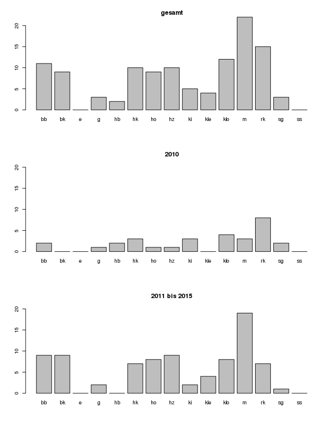

Abb. 1: Quartiere pro Schlag

```r
par(mfrow=c(3,1))
plot(gesamt.flart$schlag,
     main="gesamt",
     ylim=c(0,20)
     )
plot(
     init.flart$schlag,
     main="2010",
     ylim=c(0,20)
     )
plot(monitoring.flart$schlag,
     main="2011 bis 2015",
     ylim=c(0,20)
     )
```

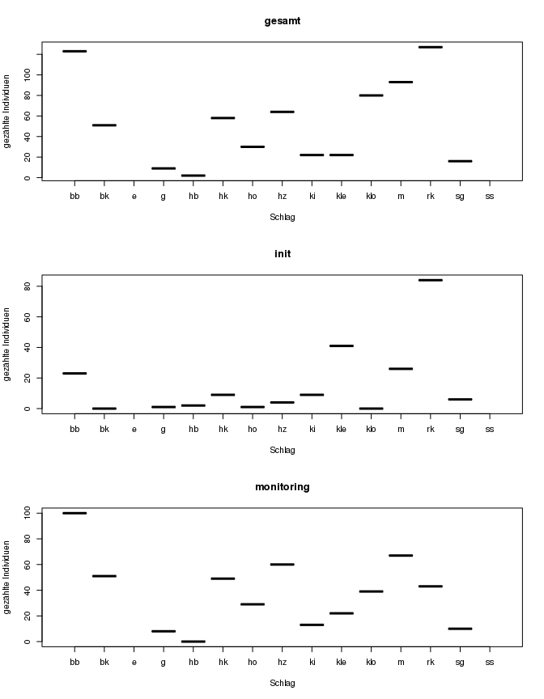

Abb. 2: Individuen pro Schlag

```r
g <- aggregate(gesamt.flart$flges, by=list(schlag=gesamt.flart$schlag), FUN=sum)
i <- aggregate(init.flart$flges, by=list(schlag=init.flart$schlag), FUN=sum)
m <- aggregate(monitoring.flart$flges, by=list(schlag=monitoring.flart$schlag), FUN=sum)
Schlag <- g$schlag
count.gesamt <- g$x
count.init <- c(i$x[1],0,i$x[2:8],0,i$x[9:11])
count.monitoring <- c(m$x[1:3],0,m$x[4:12])
count.diff <- corr * (count.monitoring - count.init)
Schlag.count <- data.frame(Schlag, count.gesamt, count.init, count.monitoring, count.diff)
names(Schlag.count) <- c("Schlag", "gesamt", "init", "monitoring", "diff")

par(mfrow=c(3,1))
plot(
     Schlag.count$gesamt ~ Schlag.count$Schlag,
     main="gesamt",
     xlab="Schlag",
     ylab="gezählte Individuen"
     )
plot(
     Schlag.count$init ~ Schlag.count$Schlag,
     main="init",
     xlab="Schlag",
     ylab="gezählte Individuen"
     )
plot(
     Schlag.count$monitoring ~ Schlag.count$Schlag,
     main="monitoring",
     xlab="Schlag",
     ylab="gezählte Individuen"
     )
```

Desweiteren können natürlich andere Effekte Standorteffekte überlagern; ein möglicher Einflussfaktor ist die Anzahl der Kästen pro Schlag, welcher als nächstes untersucht wird.

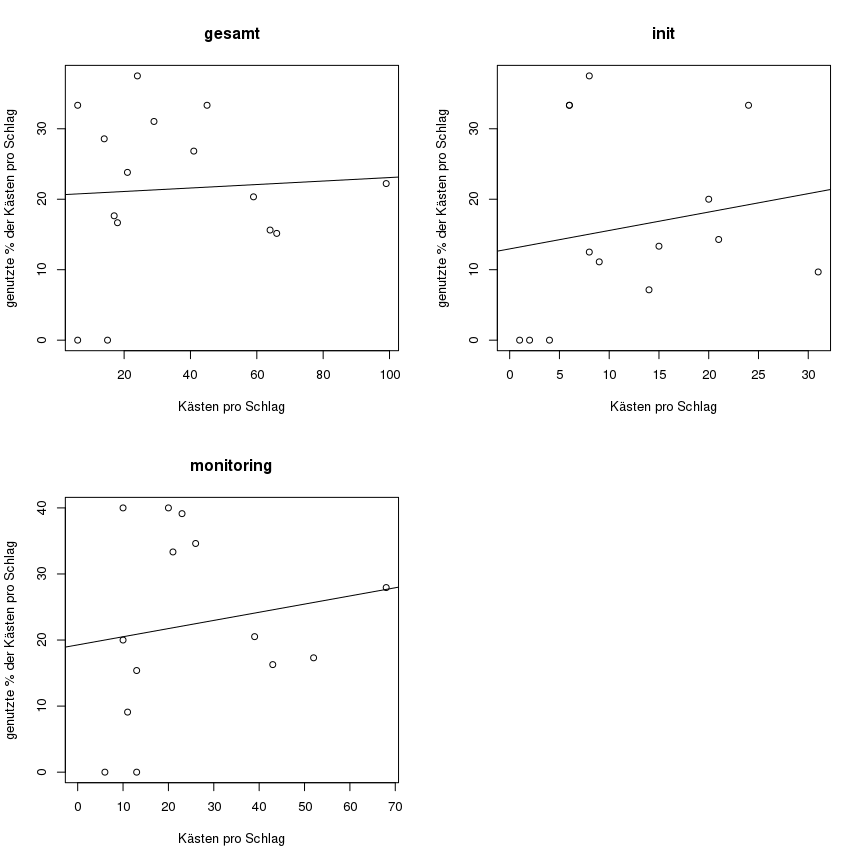

Abb. 3: Prozentuale Nutzung der Kästen in Abhängigkeit von der Anzahl der Kästen pro Schlag

```r
g.g <- summary(na.exclude(gesamt$schlag))
i.g <- summary(na.exclude(init$schlag))
m.g <- summary(na.exclude(monitoring$schlag))
m.f <- summary(na.exclude(monitoring.flart$schlag))
m.p <- m.f / m.g * 100
d.g <- corr * (m.g - i.g)

g.f <- summary(na.exclude(gesamt.flart$schlag))
g.p <- g.f / g.g * 100
i.f <- summary(na.exclude(init.flart$schlag))
i.p <- i.f / i.g * 100
d.f <- corr * (m.f - i.f)
d.p <- d.f / d.g * 100

a <- lm(g.p ~ g.g)
b <- lm(i.p ~ i.g)
c <- lm(m.p ~ m.g)

par(mfrow=c(2,2))
plot(
     g.p ~ g.g,
     main="gesamt",
     xlab="Kästen pro Schlag",
     ylab="genutzte % der Kästen pro Schlag"
     )
abline(a)
plot(
     i.p ~ i.g,
     main="init",
     xlab="Kästen pro Schlag",
     ylab="genutzte % der Kästen pro Schlag"
     )
abline(b)
plot(
     m.p ~ m.g,
     main="monitoring",
     xlab="Kästen pro Schlag",
     ylab="genutzte % der Kästen pro Schlag"
     )
abline(c)
```

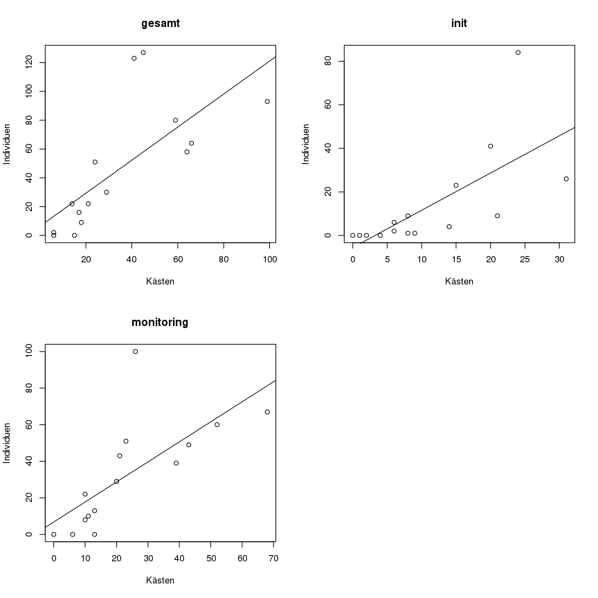

Abb. 4: Summe der Individuen in Abhängigkeit von der Anzahl der Kästen pro Schlag

```r
# Summe der Indiviuden pro Schlag
g.b <- aggregate(gesamt$flges, by=list(schlag=gesamt$schlag), FUN=sum)
i.b <- aggregate(init$flges, by=list(schlag=init$schlag), FUN=sum)
m.b <- aggregate(monitoring$flges, by=list(schlag=monitoring$schlag), FUN=sum)

# als Verktoren mit benannten Levels
g.bx <- g.b$x
names(g.bx) <- g.b$schlag
i.bx <- i.b$x
names(i.bx) <- i.b$schlag
m.bx <- m.b$x
names(m.bx) <- m.b$schlag

# Zuordnung: Individuenb pro schlag zu Kästen pro Schlag
library(plyr)

g.b <- rbind.fill.matrix(t(g.g), t(g.bx))
rownames(g.b) <- c("Kästen", "Individuen")
g.b[is.na(g.b)] <- 0
i.b <- rbind.fill.matrix(t(i.g), t(i.bx))
rownames(i.b) <- c("Kästen", "Individuen")
i.b[is.na(i.b)] <- 0
m.b <- rbind.fill.matrix(t(m.g), t(m.bx))
rownames(m.b) <- c("Kästen", "Individuen")
m.b[is.na(m.b)] <- 0

a <- lm(g.b[2,] ~ g.b[1,])
b <- lm(i.b[2,] ~ i.b[1,])
c <- lm(m.b[2,] ~ m.b[1,])

par(mfrow=c(2,2))
plot(
     g.b[2,] ~ g.b[1,],
     main="gesamt",
     xlab="Kästen",
     ylab="Individuen"
     )
abline(a)
plot(
     i.b[2,] ~ i.b[1,],
     main="init",
     xlab="Kästen",
     ylab="Individuen"
     )
abline(b)
plot(
     m.b[2,] ~ m.b[1,],
     main="monitoring",
     xlab="Kästen",
     ylab="Individuen"
     )
abline(c)
```

```r
summary(a)
```

```
##
## Call:
## lm(formula = g.b[2, ] ~ g.b[1, ])
##
## Residuals:
##     Min      1Q  Median      3Q     Max
## -26.945 -18.071  -9.899   2.737  69.575
##
## Coefficients:
##             Estimate Std. Error t value Pr(>|t|)
## (Intercept)   6.4016    13.6435   0.469  0.64669
## g.b[1, ]      1.1469     0.3135   3.658  0.00289 **
## ---
## Signif. codes:  0 '***' 0.001 '**' 0.01 '*' 0.05 '.' 0.1 ' ' 1
##
## Residual standard error: 31.51 on 13 degrees of freedom
## Multiple R-squared:  0.5072, Adjusted R-squared:  0.4693
## F-statistic: 13.38 on 1 and 13 DF,  p-value: 0.002893
```

```r
summary(b)
```

```
##
## Call:
## lm(formula = i.b[2, ] ~ i.b[1, ])
##
## Residuals:
##     Min      1Q  Median      3Q     Max
## -21.499  -7.999   0.856   3.356  48.479
##
## Coefficients:
##             Estimate Std. Error t value Pr(>|t|)
## (Intercept)   -5.545      7.132  -0.777  0.45079
## i.b[1, ]       1.711      0.496   3.450  0.00431 **
## ---
## Signif. codes:  0 '***' 0.001 '**' 0.01 '*' 0.05 '.' 0.1 ' ' 1
##
## Residual standard error: 17.16 on 13 degrees of freedom
## Multiple R-squared:  0.4779, Adjusted R-squared:  0.4377
## F-statistic:  11.9 on 1 and 13 DF,  p-value: 0.004312
```

```r
summary(c)
```

```
##
## Call:
## lm(formula = m.b[2, ] ~ m.b[1, ])
##
## Residuals:
##     Min      1Q  Median      3Q     Max
## -21.047 -10.146  -6.805   2.261  64.710
##
## Coefficients:
##             Estimate Std. Error t value Pr(>|t|)
## (Intercept)   6.8052     9.0610   0.751  0.46600
## m.b[1, ]      1.0956     0.3027   3.619  0.00312 **
## ---
## Signif. codes:  0 '***' 0.001 '**' 0.01 '*' 0.05 '.' 0.1 ' ' 1
##
## Residual standard error: 21.49 on 13 degrees of freedom
## Multiple R-squared:  0.5019, Adjusted R-squared:  0.4636
## F-statistic:  13.1 on 1 and 13 DF,  p-value: 0.003116
```

Während die Anzahl der Quartiere pro Schlag weitgehend unabhängig von der Anzahl der Kästen pro Schlag scheint, zeigt sich, dass die Anzahl der Individuen pro Schlag signifikant (0.002 < p < 0.005) mit zunehmender Kastenzahl steigt (df=13).

# 4 Wie steht es um Quantität und Qualität der künstlichen Quartiere?

```r
Schlag <- data.frame(g.g, i.g, m.g, d.g)
names(Schlag) <- c("gesamt", "init", "monitoring", "diff")

Table7 <- xtable(
         Schlag,
         caption="Tabelle 7: Anzahl der Kästen pro Schlag",
         digits=0
         )
print(Table7, type="html")
```

Tabelle 7: Anzahl der Kästen pro Schlag

|  | gesamt | init | monitoring | diff |
| --- | --- | --- | --- | --- |
| bb | 41 | 15 | 26 | 5 |
| bk | 24 | 1 | 23 | 10 |
| e | 6 | 0 | 6 | 3 |
| g | 18 | 8 | 10 | 1 |
| hb | 6 | 6 | 0 | -3 |
| hk | 64 | 21 | 43 | 10 |
| ho | 29 | 9 | 20 | 5 |
| hz | 66 | 14 | 52 | 18 |
| ki | 21 | 8 | 13 | 2 |
| kle | 14 | 4 | 10 | 3 |
| klo | 59 | 20 | 39 | 9 |
| m | 99 | 31 | 68 | 18 |
| rk | 45 | 24 | 21 | -1 |
| sg | 17 | 6 | 11 | 2 |
| ss | 15 | 2 | 13 | 5 |